# Bolt Hometask

```python
## Bolt Data Science Hometask
## by Olga Tsvetkova
```

```python
import time
import os
import sys
import logging
import fiona
import glob
import pandas as pd

#change float format in method describe()
pd.set_option('display.float_format', lambda x: '%.5f' % x)

from folium.features import DivIcon
import folium
import keplergl
import h3

import numpy as np
import datetime
from tzwhere import tzwhere
import shapely
from shapely.geometry import Polygon, Point, LineString
from shapely.ops import transform
import geopandas as gpd
from haversine import haversine, Unit
import geopy.distance

import plotly.express as px
import math
import matplotlib.pyplot as plt
#для форматирования дат
import matplotlib.dates as mdates
from ipykernel import kernelapp as app
import scipy as sc
import seaborn as sns

from functools import partial
import pyproj
from pyproj import Proj, CRS

from termcolor import colored, cprint

import getpass

import json
import ast

from sklearn.cluster import KMeans
import xgboost as xgb
from sklearn.metrics import mean_absolute_percentage_error
from geojson import Feature, FeatureCollection

%matplotlib inline
```

The task intro:

**Value Based Order Location Anticipation** Availability of supply depends on the duration of time it takes for the drivers to reach the customers. For this test task we expect you to:

1. Explore the viability of algorithmic order location anticipation based on the data provided to guide the driver towards areas of highest ride value.
2. Build a documented simple baseline model.
3. Describe how you would deploy such a model.
4. Think through and describe the randomized experiment (AB-test) for live operations.
5. The goal of the task is to understand your strengths in the data science process. Spend max 8h on it. Enjoy!

**Data** The source data is approximately 630000 rows of synthetic ride demand data which resembles the real-life situation in the city of Tallinn:

start_time - time when the order was made start_lat - latitude of the location where the order was made start_lng - longitude of the location where the order was made end_lat - latitude of the destination point end_lng - longitude of the destination point ride_value - how much monetary value is in this particular ride

Please describe what additional data would you consider useful and cite the main references used in your solution, if any.

**Comment about the task**

I did not fully understand what the task is for. For example, there are at least two different uses:

1. Draw a demand map for the next hour for drivers and offer them to relocate there.
2. Estimate the probability of an order and its value at the moment the client opens the application (view).

There is not enough data for the second case (cases where the order was not created), so I will consider the first case.

### Meet with data

```python
df = pd.read_csv('data/robotex5.csv')
df.head(10)
```

|  | start_time | start_lat | start_lng | end_lat | end_lng | ride_value |
| --- | --- | --- | --- | --- | --- | --- |
| 0 | 2022-03-06 15:02:39.329452000 | 59.40791 | 24.68984 | 59.51303 | 24.83163 | 3.51825 |
| 1 | 2022-03-10 11:15:55.177526000 | 59.44165 | 24.76271 | 59.42645 | 24.78308 | 0.50750 |
| 2 | 2022-03-06 14:23:33.893257000 | 59.43540 | 24.74980 | 59.43190 | 24.76159 | 0.19025 |
| 3 | 2022-03-03 09:11:59.104192000 | 59.40692 | 24.65901 | 59.38109 | 24.64165 | 0.75600 |
| 4 | 2022-03-06 00:13:01.290346000 | 59.43494 | 24.75364 | 59.48920 | 24.87617 | 2.27100 |
| 5 | 2022-03-02 07:17:34.858783000 | 59.43361 | 24.71274 | 59.43521 | 24.74884 | 0.50275 |
| 6 | 2022-03-17 11:08:25.117959000 | 59.39896 | 24.71086 | 59.44098 | 24.76022 | 1.35200 |
| 7 | 2022-03-18 14:34:56.333676000 | 59.41681 | 24.79900 | 59.40650 | 24.68392 | 1.62200 |
| 8 | 2022-03-13 19:19:32.659761000 | 59.43232 | 24.76052 | 59.42330 | 24.74921 | 0.29550 |
| 9 | 2022-03-17 16:20:20.028387000 | 59.41078 | 24.72122 | 59.43990 | 24.77176 | 1.06975 |

```python
df.info()
```

```
<class 'pandas.core.frame.DataFrame'>
RangeIndex: 627210 entries, 0 to 627209
Data columns (total 6 columns):
 #   Column      Non-Null Count   Dtype
---  ------      --------------   -----
 0   start_time  627210 non-null  object
 1   start_lat   627210 non-null  float64
 2   start_lng   627210 non-null  float64
 3   end_lat     627210 non-null  float64
 4   end_lng     627210 non-null  float64
 5   ride_value  627210 non-null  float64
dtypes: float64(5), object(1)
memory usage: 28.7+ MB
```

> All values non-null - good!

### Data validation

```python
df.ride_value.describe()
```

```
count   627210.00000
mean         2.26138
std         44.88989
min          0.10763
25%          0.54525
50%          1.05900
75%          1.71200
max       3172.70100
Name: ride_value, dtype: float64
```

> There are some outliers. Drop them

```python
df = df[df.ride_value <= df.ride_value.quantile(0.99)] #drop outliers
```

```python
print('Time period : from {} to {}'.format(min(df.start_time), max(df.start_time)))
```

```
Time period : from 2022-03-01 00:00:07.936317000 to 2022-03-28 23:59:53.175658000
```

```python
df['start_time'] = pd.to_datetime(df.start_time)

#check Timezone
tz = tzwhere.tzwhere()
df['tz'] = df.apply(lambda x: tz.tzNameAt(x.start_lat, x.start_lng), axis = 1)
df.tz.unique()
```

```
array(['Europe/Tallinn', None], dtype=object)
```

> some points in the sea - they should be deleted

```python
df = df[~df['tz'].isna()] #delete points in the sea
```

```python
#round datetime to start of Hour

#this doesn't work due some stranges like '2022-03-01 00:00:00.000000999'
#TODO: solve it
#df['startOfHour'] = df.start_time.apply(lambda x: x.replace(minute=0, second=0, microsecond=0))


def startOfHour(date_):
    return date_.strftime("%Y-%m-%d %H:00:00")

df['startOfHour'] = df.start_time.apply(lambda x: startOfHour(x))
df['startOfHour'] = pd.to_datetime(df.startOfHour)
```

```python
df.head()
```

|  | start_time | start_lat | start_lng | end_lat | end_lng | ride_value | tz | startOfHour |
| --- | --- | --- | --- | --- | --- | --- | --- | --- |
| 0 | 2022-03-06 15:02:39.329452 | 59.40791 | 24.68984 | 59.51303 | 24.83163 | 3.51825 | Europe/Tallinn | 2022-03-06 15:00:00 |
| 1 | 2022-03-10 11:15:55.177526 | 59.44165 | 24.76271 | 59.42645 | 24.78308 | 0.50750 | Europe/Tallinn | 2022-03-10 11:00:00 |
| 2 | 2022-03-06 14:23:33.893257 | 59.43540 | 24.74980 | 59.43190 | 24.76159 | 0.19025 | Europe/Tallinn | 2022-03-06 14:00:00 |
| 3 | 2022-03-03 09:11:59.104192 | 59.40692 | 24.65901 | 59.38109 | 24.64165 | 0.75600 | Europe/Tallinn | 2022-03-03 09:00:00 |
| 4 | 2022-03-06 00:13:01.290346 | 59.43494 | 24.75364 | 59.48920 | 24.87617 | 2.27100 | Europe/Tallinn | 2022-03-06 00:00:00 |

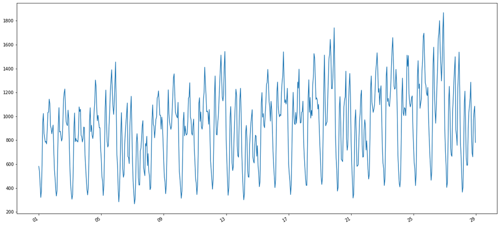

```python
#plot the data

fig , ax = plt.subplots(figsize=(20,10))
plt.plot(df.groupby('startOfHour').size())
ax.xaxis.set_major_formatter(mdates.DateFormatter('%d'))
# rotate and align the tick labels so they look better
fig.autofmt_xdate()

plt.show()
```

> You can see hourly, weekly trends and special behavior on Fri, Sat, Sun. Let's separate them into groups (it will be in the next chapter)

## We should agreggate geo data due small dataset.

**I decided to use `sum(ride_value)` because we want to know demand in current location**

There are several ways:

1. The simplest way is to use Uber H3;
2. Load from OSM API district boundaries;
3. Clustering and Reginalization.

I don't have enough time, so I use the first way.

### Uber H3

Lets' try with H3 number 6, because its average radius is 8.5km which is close to alloew estimated radius to arrival (https://h3geo.org/docs/core-library/restable/)

```python
#get name of hexagons for each point
df['h6'] = df.apply(lambda x : h3.geo_to_h3(x.start_lat, x.start_lng, 6), axis = 1)
```

```python
df.head()
```

|  | start_time | start_lat | start_lng | end_lat | end_lng | ride_value | tz | startOfHour | h6 |
| --- | --- | --- | --- | --- | --- | --- | --- | --- | --- |
| 0 | 2022-03-06 15:02:39.329452 | 59.40791 | 24.68984 | 59.51303 | 24.83163 | 3.51825 | Europe/Tallinn | 2022-03-06 15:00:00 | 86089bc5fffffff |
| 1 | 2022-03-10 11:15:55.177526 | 59.44165 | 24.76271 | 59.42645 | 24.78308 | 0.50750 | Europe/Tallinn | 2022-03-10 11:00:00 | 86089b1a7ffffff |
| 2 | 2022-03-06 14:23:33.893257 | 59.43540 | 24.74980 | 59.43190 | 24.76159 | 0.19025 | Europe/Tallinn | 2022-03-06 14:00:00 | 86089b1a7ffffff |
| 3 | 2022-03-03 09:11:59.104192 | 59.40692 | 24.65901 | 59.38109 | 24.64165 | 0.75600 | Europe/Tallinn | 2022-03-03 09:00:00 | 86089bc5fffffff |
| 4 | 2022-03-06 00:13:01.290346 | 59.43494 | 24.75364 | 59.48920 | 24.87617 | 2.27100 | Europe/Tallinn | 2022-03-06 00:00:00 | 86089b1a7ffffff |

```python
#group by hexagon and hour
df_aggr = df[['ride_value', 'h6', 'startOfHour']].groupby(['h6', 'startOfHour']).sum().reset_index()
```

```python
df_aggr.head()
```

|  | h6 | startOfHour | ride_value |
| --- | --- | --- | --- |
| 0 | 86089b017ffffff | 2022-03-01 07:00:00 | 3.28600 |
| 1 | 86089b017ffffff | 2022-03-03 11:00:00 | 3.01675 |
| 2 | 86089b017ffffff | 2022-03-04 20:00:00 | 2.99350 |
| 3 | 86089b017ffffff | 2022-03-06 22:00:00 | 2.82150 |
| 4 | 86089b017ffffff | 2022-03-07 20:00:00 | 4.08900 |

```python
#get centers of hexagons

h3_centers = list()
for h6 in df_aggr.h6.unique():
    lat, lon = h3.h3_to_geo(h6)
    h3_centers.append({'h6': h6, 'h6_lat':  lat, 'h6_lon': lon})
```

```python
#add centers of hexagons to aggregated DataFrame
df_aggr = df_aggr.join(pd.DataFrame(h3_centers).set_index('h6'), how = 'left', on='h6')
```

```python
df_aggr.head()
```

|  | h6 | startOfHour | ride_value | h6_lat | h6_lon |
| --- | --- | --- | --- | --- | --- |
| 0 | 86089b017ffffff | 2022-03-01 07:00:00 | 3.28600 | 59.52003 | 24.95908 |
| 1 | 86089b017ffffff | 2022-03-03 11:00:00 | 3.01675 | 59.52003 | 24.95908 |
| 2 | 86089b017ffffff | 2022-03-04 20:00:00 | 2.99350 | 59.52003 | 24.95908 |
| 3 | 86089b017ffffff | 2022-03-06 22:00:00 | 2.82150 | 59.52003 | 24.95908 |
| 4 | 86089b017ffffff | 2022-03-07 20:00:00 | 4.08900 | 59.52003 | 24.95908 |

```python
# save dataset for Kepler visualisation. I did it more quickly in UI
df_aggr.to_csv('agg_for_kep.csv')
```

## Feature Engeniring

features:

1. orders last day
2. orders last hour
3. orders prev week

TODO:

1. cumsum from startOfDay

```python
def calc_features(df = df, timecolumn = 'start_time'):
    '''function return DataFrame with 7 new columns
    1. get hour from time column
    2. get weekday from time column
    3. get day from time column
    4. make 4 groups for weekdays:
    5. get seconds from start of day in time column
    6 and 7 are cyclical continuous features - 24-hour time'''

    df['hour'] = df[timecolumn].apply(lambda x: x.hour)
    df['weekday'] = df[timecolumn].apply(lambda x: x.weekday())
    df['day'] = df[timecolumn].apply(lambda x: x.day)
    df['weekdaygroups'] = df['weekday'].apply(lambda x: 0 if x < 5 else x)
        #some tricks with time transformation
    df['seconds'] = (df[timecolumn].dt.hour*60+df[timecolumn].dt.minute)*60\
                       + df[timecolumn].dt.second #seconds from start of day
    df['sin_seconds_zone'] = np.sin(2 * np.pi / 86400 * df.seconds)
    df['cos_seconds_zone'] = np.cos(2 * np.pi / 86400 * df.seconds)

    return df
```

```python
df_aggr = calc_features(df_aggr, timecolumn='startOfHour')
```

```python
def get_value_prev_period(df_aggr, periodname='hours', delta = 1, aggr_name = 'ride_value'):
    '''function return dataframe with new column where column is shifted by delta periods
        df_aggr : DataFrame
        periodname : same as in the datetime.timedelta function
        delta : counts of shifted periodname
        aggr_name : name of shifted column
    '''
    args = {periodname : delta}
    df_aggr2 = df_aggr[['startOfHour', aggr_name, 'h6']]
    df_aggr2.loc[:, 'startOfHour'] = df_aggr2.startOfHour + datetime.timedelta(**args) # shift by 2 weeks
    df_aggr = df_aggr.merge(df_aggr2, on=['startOfHour', 'h6'], how='left', suffixes = ('', '_prev_'+str(delta)+periodname))
    return df_aggr
```

```python
#prev hour
df_aggr = get_value_prev_period(df_aggr)
#prev day
df_aggr = get_value_prev_period(df_aggr, periodname = 'days')
#prev week
df_aggr = get_value_prev_period(df_aggr, periodname = 'weeks')
```

```python
df_aggr.info()
```

```
<class 'pandas.core.frame.DataFrame'>
Int64Index: 10340 entries, 0 to 10339
Data columns (total 15 columns):
 #   Column                  Non-Null Count  Dtype
---  ------                  --------------  -----
 0   h6                      10340 non-null  object
 1   startOfHour             10340 non-null  datetime64[ns]
 2   ride_value              10340 non-null  float64
 3   h6_lat                  10340 non-null  float64
 4   h6_lon                  10340 non-null  float64
 5   hour                    10340 non-null  int64
 6   weekday                 10340 non-null  int64
 7   day                     10340 non-null  int64
 8   weekdaygroups           10340 non-null  int64
 9   seconds                 10340 non-null  int64
 10  sin_seconds_zone        10340 non-null  float64
 11  cos_seconds_zone        10340 non-null  float64
 12  ride_value_prev_1hours  9293 non-null   float64
 13  ride_value_prev_1days   9058 non-null   float64
 14  ride_value_prev_1weeks  7119 non-null   float64
dtypes: datetime64[ns](1), float64(8), int64(5), object(1)
memory usage: 1.3+ MB
```

### Plot data

```python
df_aggr[df_aggr.day < 21].groupby('startOfHour').size().sort_values()
```

```
startOfHour
2022-03-04 02:00:00    10
2022-03-17 02:00:00    10
2022-03-06 02:00:00    11
2022-03-13 03:00:00    11
2022-03-03 04:00:00    11
                       ..
2022-03-18 20:00:00    18
2022-03-16 08:00:00    19
2022-03-16 20:00:00    19
2022-03-20 21:00:00    19
2022-03-06 15:00:00    19
Length: 480, dtype: int64
```

```python
def reverse_coords(point):
    '''function reverse lat, lon in h3 geo boundary '''
    return [point[::-1] for point in h3.h3_to_geo_boundary(point, geo_json=False)]

def hexagons_dataframe_to_geojson(df_hex, hex_id_field,geometry_field, value_field):
    '''return geojson with geometry stored in geometry_field
    hex_id_field : id in geojson
    value_field : property in geojson '''

    list_features = []

    for i, row in df_hex.iterrows():
        feature = Feature(geometry = row[geometry_field],
                          id = row[hex_id_field],
                          properties = {"value": row[value_field]})
        list_features.append(feature)

    feat_collection = FeatureCollection(list_features)

    return feat_collection
```

```python
df_plot = df_aggr[df_aggr['startOfHour'] == '2022-03-06 15:00:00'][['h6', 'ride_value']]

def plot_map(df_plot = df_plot, plotting_column_name = 'ride_value'):
    '''function plot choropleth on map using plotly express
        value for choropleth stored in plotting_column_name
    '''
    df_plot['h3geom'] = df_plot.h6.apply(lambda x: Polygon(reverse_coords(x)))

    geojson_obj = hexagons_dataframe_to_geojson(df_plot, hex_id_field = 'h6'
                                                ,geometry_field = 'h3geom'
                                                , value_field = plotting_column_name )

    fig = (px.choropleth_mapbox(
                        df_plot,
                        geojson=geojson_obj,
                        locations='h6',
                        color=plotting_column_name,
                        color_continuous_scale="Viridis",
                        range_color=(0,df_plot[plotting_column_name].max()), mapbox_style='carto-positron',
                        zoom=7,
                        center = {"lat": 59.437425, "lon": 24.745137},
                        opacity=0.7,
                        labels={'count':'# of fire ignitions '}))
    fig.update_layout(margin={"r":0,"t":0,"l":0,"b":0})
    fig.show()

plot_map()
```

[interactive chart not shown]

> the main value is concentrated in the center, as expected. So we can add feature : distance to center

```python
center =  (59.437425 , 24.745137) #lat, lon
```

```python
# calculate distance center of Tallin
df_aggr['dist_to_center'] = df_aggr.apply(lambda x: haversine((x.h6_lat, x.h6_lon), center, unit = 'km'), axis = 1)
```

```python
df_aggr.head(3)
```

|  | h6 | startOfHour | ride_value | h6_lat | h6_lon | hour | weekday | day | weekdaygroups | seconds | sin_seconds_zone | cos_seconds_zone | ride_value_prev_1hours | ride_value_prev_1days | ride_value_prev_1weeks | dist_to_center |
| --- | --- | --- | --- | --- | --- | --- | --- | --- | --- | --- | --- | --- | --- | --- | --- | --- |
| 0 | 86089b017ffffff | 2022-03-01 07:00:00 | 3.28600 | 59.52003 | 24.95908 | 7 | 1 | 1 | 0 | 25200 | 0.96593 | -0.25882 | nan | nan | nan | 15.17677 |
| 1 | 86089b017ffffff | 2022-03-03 11:00:00 | 3.01675 | 59.52003 | 24.95908 | 11 | 3 | 3 | 0 | 39600 | 0.25882 | -0.96593 | nan | nan | nan | 15.17677 |
| 2 | 86089b017ffffff | 2022-03-04 20:00:00 | 2.99350 | 59.52003 | 24.95908 | 20 | 4 | 4 | 0 | 72000 | -0.86603 | 0.50000 | nan | nan | nan | 15.17677 |

## baseline - XGboost

There are two options:

1. to use time series prophet, but it would have to build your own series for each zone;
2. to train the XGboost, where the coordinates are added as a feature.

```python
df_aggr.columns
```

```
Index(['h6', 'startOfHour', 'ride_value', 'h6_lat', 'h6_lon', 'hour',
       'weekday', 'day', 'weekdaygroups', 'seconds', 'sin_seconds_zone',
       'cos_seconds_zone', 'ride_value_prev_1hours', 'ride_value_prev_1days',
       'ride_value_prev_1weeks', 'dist_to_center'],
      dtype='object')
```

```python
# read the data
columns = ['h6_lat', 'h6_lon', 'weekdaygroups',  'sin_seconds_zone' , 'cos_seconds_zone'
           , 'ride_value_prev_1hours', 'ride_value_prev_1days',  'ride_value_prev_1weeks'
          , 'dist_to_center']
train = df_aggr[df_aggr.day < 22][columns]
trlabel = df_aggr[df_aggr.day < 22]['ride_value']

test = df_aggr[df_aggr.day >= 22][columns] #last week for the test
telabel = df_aggr[df_aggr.day >= 22]['ride_value']
dtrain = xgb.DMatrix(train, label=trlabel)
dtest = xgb.DMatrix(test, label=telabel)

# specify parameters via map
param = {'max_depth': 4, 'objective':'reg:squarederror'}
num_round = 10
bst = xgb.train(param, dtrain, num_round, )
# make prediction
preds = bst.predict(dtest)
```

### Calculate model error using MAPE

```python
print('MAPE : %0.2f' % mean_absolute_percentage_error(telabel, preds))
```

```
MAPE : 0.46
```

> Pretty good result. But in order to make sense to use the model, MAPE 30% is better. To improve the result, you may add information about client incetives and information about the weather.

### Let's look at feature importance

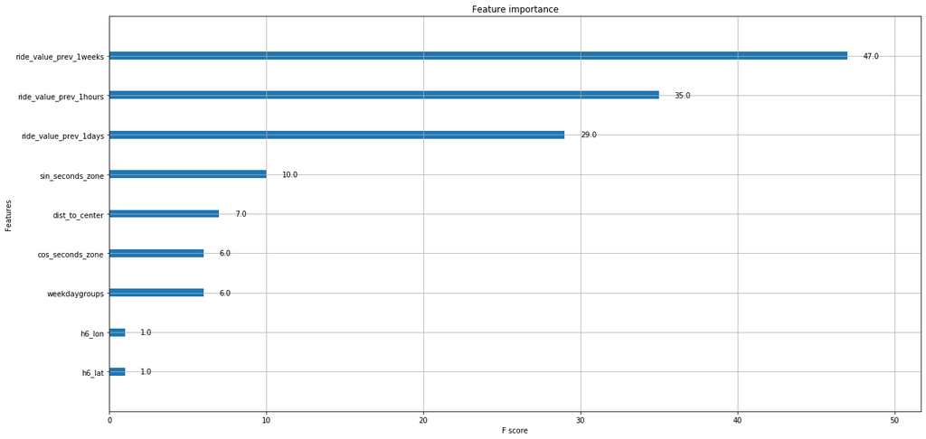

```python
fig, ax = plt.subplots(figsize = (20,10))
xgb.plot_importance(bst, ax=ax)

plt.show()
```

### Plot mean error by hexagons

```python
df_aggr_test = df_aggr[df_aggr.day >= 22] # select test data (last week)
```

```python
df_aggr_test['pred'] = preds # add predictions
```

```python
column_name = 'MAPE'

df_aggr_test = df_aggr_test[['h6', 'pred', 'ride_value']].groupby('h6').apply(lambda x: \
                                                                         mean_absolute_percentage_error(x.ride_value
                                                                                                        , x.pred))

df_aggr_test.name = column_name
df_aggr_test = pd.DataFrame(df_aggr_test.reset_index())


plot_map(df_plot = df_aggr_test, plotting_column_name = column_name)
```

[interactive chart not shown]

> The error increases with distance from the city center, you can explore further what causes the demand in the outskirts.

## Describe how you would deploy such a model.

I am oriented on [Google ML best practise](https://cloud.google.com/architecture/mlops-continuous-delivery-and-automation-pipelines-in-machine-learning), so the best solution will be like that:

[figure not shown]

To deploy the model, firstly, it is necessary to prepare the data collection process. There are two types of features in the model:

1. Pre-aggregating features once a day or rarely. (for example, last week's orders or distance to the center)
2. Features that calucalting directly before predictions. (for example, orders for the last hour)

The first type of feature requires a data window and a regular mart collection process (ETL).

After data collection the stage step is validation and data preparation. During the pipline for model training, it is important to validate the data and set up triggers for anomaly detection. The collected data is stored in a database.

After preparing the window (dataset), you can train the model with scripts. At this stage, it is important to log training parameters and metrics during testing. If models update automatically, it is necessary to set up triggers on the error value (MAPE) on the test and control. Since time series require constant updating, this step cannot be omitted.

Next, the model is uploaded to the repository and updated in the API. The implementation of this step depends on the infrastructure of the team: you can deploy Docker and FastAPI on the server, use S3 for storage models. And you can use MLFlow , which makes the the model logging easier, but more difficult in terms of maintaining the service (MLOps). It is important for the model to write the processing of "bad" input data - gaps, new hexagons, anomalous values.

When you first run the model, you need to perform load testing on the API and understand whether there is enough capacity to quickly respond to requests from highly loaded systems. This model will probably run once an hour, so the requirements are lighter here.

This model can run on crone and recalculate. For this simple scheduler, you can use either lightweight python libraries. Advanced tool is AirFLow.

The results of the model are put into the production database for their further visualization on map layers in the driver application. (I think this is the MVP use case for the model)

## Think through and describe the randomized experiment (AB-test) for live operations.

The main goal of modeling, as written in the problem, is to increase the conversion from order to trip. This is achieved by reducing the supply ETA or increasing the supply in a particular region.

You can use an A/B experiment with the main ETA metric. The t-test can be used to test the hypothesis of a decrease in the average car delivery time.

Since this model cannot be divided into groups A/B in the usual way due to the network effect, switchback A/A/B testing can be used.In this test unit-level will be hexagones and time. Since the data will be aggregated to the hexagon level, there will be significantly fewer of observations, and for the convergence of the experiment, you can use t-test + cuped method.

To test increasing the conversion from order to trip you may use the t-test and delta method.

Before the experiment, it is worth to take an A/A experiment to evaluate the convergence of the metrics, the applicability of the test and determine the size of the hexagon and the time interval for given alpha and power.

Experiment stops when when the groups have reached the size to determine minimum detectable effect.